# HW1

Jackson Evans

## R Markdown

Question 3.5 a) Check assumptions

1. Our data are random sample.
2. Our data values are independent. There could be extra delay from another delay. Eg., one delay causes another, however aidlines account for this and the error is minimal.
3. Our population distributions must have similar variances. (around 1000)

Ho: mu(united delay) = mu(american delay) H1: mu(united delay) != mu(american delay)

```r
library(resampledata)
```

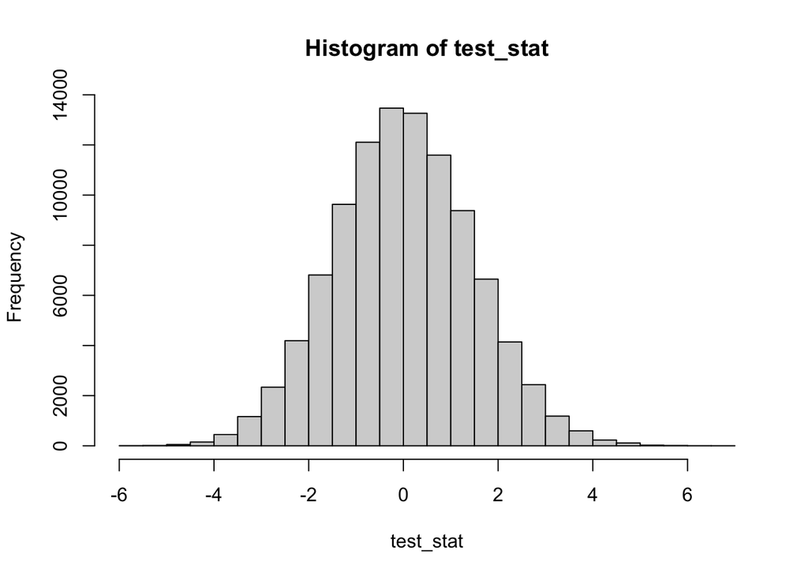

```r
pool <- FlightDelays$Delay

united <- subset(FlightDelays, Carrier == "UA")
american <- subset(FlightDelays, Carrier == "AA")

n1<- nrow(united)

test_stat <- NULL
for(i in 1:100000){
  indexes <- sample(1:length(pool), size=n1, replace = FALSE) #random sample size 39

  group1 <- pool[indexes]
  group2 <- pool[-indexes]

  test_stat[i] <- mean(group1)-mean(group2)

}

#Calculate p-value
hist(test_stat)
```

```r
actual_stat<- mean(united$Delay)-mean(american$Delay)
mean(test_stat >= actual_stat)*2
```

```
## [1] 0.00012
```

2. Check assumptions
   1. Our data are random sample.
   2. Our data values are independent. There could be extra delay from another delay. Eg., one delay causes another, however aidlines account for this and the error is minimal.
   3. Our population distributions must have similar variances. (around 1000)

Ho: mu(may delays) = mu(june delays) H1: mu(may delays) != mu(june delays)

```r
poolb <- FlightDelays$Delay
may <- poolb[1:1999]
june <- poolb[2000:4029]

n1<- length(may)

test_stat <- NULL
for(i in 1:10000){
  indexes <- sample(1:length(poolb), size=n1, replace = FALSE) #random sample size 39

  group1 <- poolb[indexes]
  group2 <- poolb[-indexes]

  test_stat[i] <- mean(group1)-mean(group2)

}

#Calculate p-value
#hist(test_stat)
actual_stat <- mean(june)-mean(may)
2*(sum(test_stat >= actual_stat)+1)/(length(test_stat))
```

```
## [1] 4e-04
```

3.7) Check assumptions

1. Our data are random sample.
2. Our data values are independent. There could be extra delay from another delay. Eg., one delay causes another, however aidlines account for this and the error is minimal.
3. Our population distributions must have similar variances. (around 1000)

```r
pool <- FlightDelays$Delay


obs_united_mean <- mean(united$Delay)
obs_united_sum <- sum(united$Delay)
obs_american_sum <- sum(american$Delay)
obs_diff_means <- mean(united$Delay)-mean(american$Delay)

n1<- nrow(united)

mean_test_stat <- NULL
sum_test_stat <- NULL
diff_test_stat <- NULL
for(i in 1:100000){
  indexes <- sample(1:length(pool), size=n1, replace = FALSE) #random sample size 39

  group1 <- pool[indexes]
  group2 <- pool[-indexes]

  mean_test_stat[i] <- mean(group1)
  sum_test_stat[i] <- sum(group1)
  diff_test_stat[i] <- mean(group1)-mean(group2)

}
mean_actual_stat <- obs_united_mean
#mean p-value
mean(mean_test_stat >= mean_actual_stat)*2
```

```
## [1] 8e-05
```

```r
sum_actual_stat <- obs_american_sum - obs_united_sum
#sum p-value:
mean(sum_test_stat >= obs_united_sum)*2
```

```
## [1] 8e-05
```

```r
diff_actual_stat <- obs_diff_means
#difference p-value:
mean(diff_test_stat >= diff_actual_stat)*2
```

```
## [1] 8e-05
```

All p-values are the same, approximately 8e-05. So they are all significant. This is because the instances where the United delays are particularly high, resulting in a high mean difference, sum and mean.

3.15) a)

The data is an example of matched pairs data because each product has the same data, including size, units, and unit type, except for price dependent on the variable we are investigating.

```r
#Target mean:
target_mean <- mean(Groceries$Target)
target_mean
```

```
## [1] 2.762333
```

```r
#Walmart mean:
walmart_mean <- mean(Groceries$Walmart)
walmart_mean
```

```
## [1] 2.705667
```

```r
#Target mode:
target_mode <- mode(Groceries$Target)
target_mode
```

```
## [1] "numeric"
```

```r
#Walmart mode:
walmart_mode <- mode(Groceries$Walmart)
walmart_mode
```

```
## [1] "numeric"
```

```r
#Target median:
target_median <- median(Groceries$Target)
target_median
```

```
## [1] 2.545
```

```r
#Walmart median:
walmart_median <- median(Groceries$Walmart)
walmart_median
```

```
## [1] 2.34
```

```r
#Target IQR:
target_iqr <- IQR(Groceries$Target)
target_iqr
```

```
## [1] 1.3125
```

```r
#Walmart IQR:
walmart_iqr <- IQR(Groceries$Walmart)
walmart_iqr
```

```
## [1] 1.195
```

There were no repeated values to compute a mode.

Check assumptions

1. Our data are random sample.
2. Our data values are independent. There could be bias as Target and Walmart are competitors, but due to the amount of items sold by each enterprise, it shouldn’t significantly affect the data.
3. Our population distributions must have similar variances. (around 1000)

Ho: mu(target mean)= mu(walmart mean) H1: mu(target mean) != (walmart mean)

Run a matched-pairs p-value test.

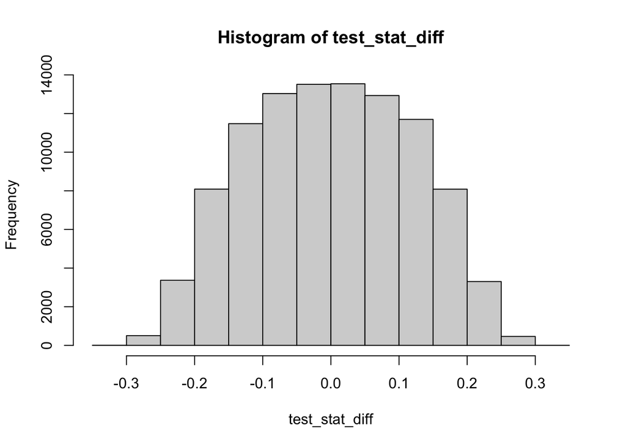

```r
diff <- Groceries$Target - Groceries$Walmart
actual_test_stat <- mean(diff)

test_stat_diff <- NULL

for(i in 1:100000){
  sign <- sample(c(-1,1), size = length(diff), replace = TRUE)
  random_diff <- diff*sign #randomly shuffles signs of each observation - independently
  test_stat_diff[i] <- mean(random_diff)
}
hist(test_stat_diff)
```

```r
mean(abs(test_stat_diff) >= actual_test_stat)
```

```
## [1] 0.69218
```

4. Creating a histogram:

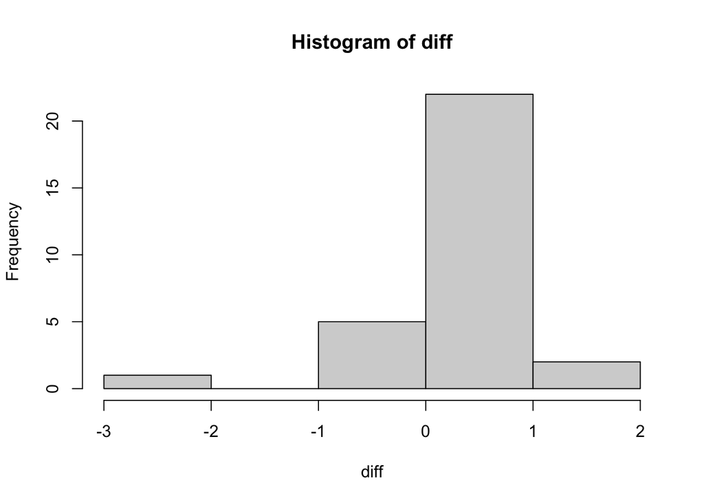

```r
diff <- Groceries$Target - Groceries$Walmart
hist(diff)
```

This value for Quaker Oats Life cereal has a difference near $3, almost double the price at Walmart than at Target. It is by far the most sizeable difference.

5. Check assumptions
1. Our data are random sample.
2. Our data values are independent.
3. Our population distributions must have similar variances. (around 1000)

Ho: mu(target mean)= mu(walmart mean) H1: mu(target mean) != (walmart mean)

Run a matched-pairs p-value test excluding Quaker Oats Life Cereal Original.

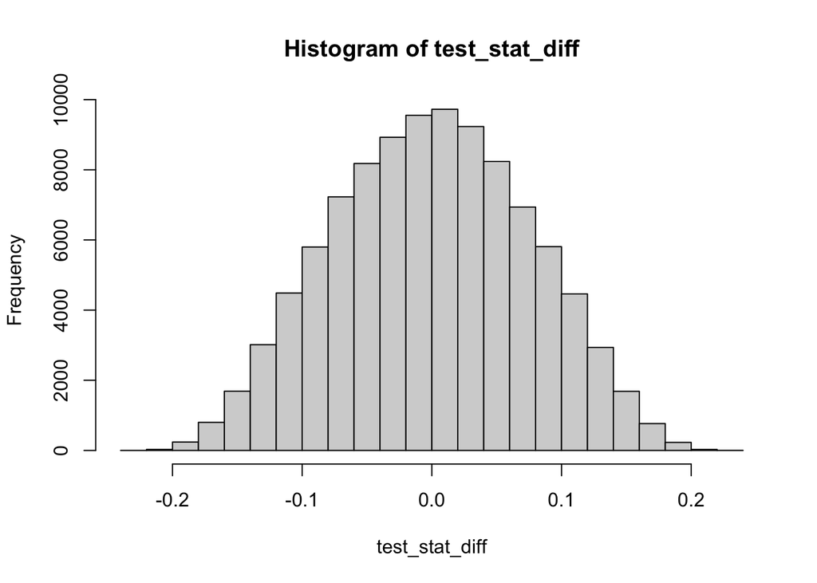

```r
diff <- Groceries$Target - Groceries$Walmart
no_life_diff <- diff[diff!= -2.82] #excluding the outlier value.
actual_test_stat <- mean(no_life_diff)

test_stat_diff <- NULL

for(i in 1:100000){
  sign <- sample(c(-1,1), size = length(no_life_diff), replace = TRUE)
  random_diff <- no_life_diff*sign #randomly shuffles signs of each observation - independently
  test_stat_diff[i] <- mean(random_diff)
}
hist(test_stat_diff)
```

```r
mean(abs(test_stat_diff) >= actual_test_stat)
```

```
## [1] 0.02613
```

Diamonds Running a p test with a test statistic of the sum of differences of median from observed statistic.

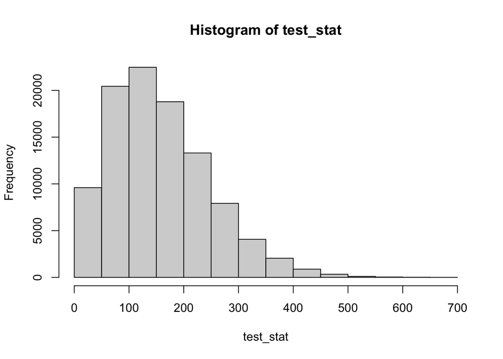

```r
library(ggplot2)

#Ho: median(H) = median(I) = median(J)
#H1: median(H) != median(I) or median(H) != median(J) or median(I) != median(J)
h <- subset(diamonds, color == "H")
i <- subset(diamonds, color == "I")
j <- subset(diamonds, color == "J")

hrows <- nrow(h)
irows <- nrow(i)
jrows <- nrow(j)

pool <- c(h$price, i$price, j$price)
n1<-length(pool)
h_median <- median(h$price)
i_median <- median(i$price)
j_median <- median(j$price)

actual_stat <- abs(h_median-median(pool)) + abs(i_median-median(pool)) + abs(j_median-median(pool))

test_stat <- NULL
for(i in 1:100000){
  indexes <- sample(1:length(pool), size=n1, replace = FALSE)

  group1 <- pool[indexes[1:hrows]]
  group2 <- pool[indexes[(hrows+1):(hrows+irows)]]
  group3 <- pool[indexes[(hrows+irows+1):(hrows+irows+jrows)]]

  m_1 <- abs(median(group1) - median(pool))
  m_2 <- abs(median(group2) - median(pool))
  m_3 <- abs(median(group3) - median(pool))

  test_stat[i] <- m_1 + m_2 + m_3

}
#find p value
hist(test_stat)
```

```r
2*(sum((test_stat >= actual_stat))+1)/(length(test_stat))
```

```
## [1] 2e-05
```

Our p-value is 2e-05.

Conclusions in context for each of the following cases:

i)The diamonds in this data set are a random selection of diamonds from all diamonds in the world.

Check assumptions

1. Our data are random sample.
2. Our data values are independent.
3. Our population distributions must have similar variances. (around 1000)

```
In this case, since the data are a true random sample, we take the p-value of
2e-05 as statistically significant and reject the null hypothesis that
the median price of H, I, and J colors are equal. Therefore we accept the
alternative hypothesis that they are not equal.
```

ii)The diamonds in this data set are all of the diamonds in this particular jeweler’s collection.

Check assumptions

1. Our data are a population.
2. Our data values are possibly independent. The jeweler likely has bias to collect diamonds that they like, or that will sell well. Therefore if one color sells better than others, the jeweler may increase the prices, #hence increasing the median.
3. Our population distributions must have similar variances. (around 1000)

In this case, since the data are a population - all the diamonds in the jeweler’s collection, we need not look at the p-value, as the medians of the different colors are different, so we reject the null hypothesis.

3. The diamonds in this data set are a random selection of diamonds from this particular jeweler’s collection

Check assumptions

1. Our data are random sample.
2. Our data values are possibly independent. The jeweler likely has bias to collect diamonds that they like, or that will sell well. Therefore if one color sells better than others, the jeweler may increase the prices, hence increasing the median.
3. Our population distributions must have similar variances. (around 1000)

In this case, since the data are a random sample, we take the p-value of 2e-05 as statistically significant and reject the null hypothesis that the median price of H, I, and J colors are equal. We don’t, however, have enough information to categorically state the prices are universally different. We can say that the median prices of the H, I, and J colored diamonds in the jeweler’s collection are not equal, given the significancce of the p-value.

4. It is unclear exactly how these data were collected.

Check assumptions

1. Our data are collected via unknown methods.
2. Our data values are possibly independent, but we can’t be sure without more information of their collection. They could be the most prized gems hiested from museums for all we know.
3. Our population distributions must have similar variances. (around 1000)

In this case, since the data are is collected via an unknown means and we are entirely unsure about their independence, it would be unwise to conclude anything based on the p-value, other than the observed medians are different.